# Scoring Project

Author

JELASSI Meriem, SHISHIKHANOVA Laoura, DROZD Yekaterina

# Presentation: **Scoring Model for Predicting Corporate Bankruptcies**

## Context

Predicting corporate bankruptcies is a critical task for investors, financial institutions, and companies themselves. Accurate predictions help mitigate risks, allocate resources efficiently, and prevent significant losses. This project focuses on building a scoring model to predict the likelihood of default for publicly traded U.S. companies.

## Expected Results

- Identify companies with a high risk of default with satisfactory accuracy.
- Gain deeper insights into the factors influencing bankruptcy likelihood.
- Propose a practical solution for managing financial risks.

# Practical 1 - Dataset Construction

## Step 1: Loading data and preparation

### Load necessary libraries

```r
libraries <- c(
  "ParBayesianOptimization",
  "zoo",
  "caret",
  "car",
  "tidyverse",
  "scales",
  "qgraph",
  "RSQLite",
  "dbplyr",
  "RPostgres",
  "glmnet",
  "caret",
  "xgboost",
  "pROC",
  "ggcorrplot",
  "ggplot2",
  "naniar",
  "mice",
  "doParallel",
  "corrplot",
  "ROSE"
)

for (lib in libraries) {
  if (!requireNamespace(lib, quietly = TRUE)) {
    install.packages(lib)  # Installer si non présent
  }
  library(lib, character.only = TRUE)
}
```

### Connect to WRDS database

First, we need to securely connect our R environment to the WRDS PostgreSGL database, to query financial data on their platform.

```r
readRenviron("~/.Renviron")
wrds <- dbConnect(
Postgres(),
host = "wrds-pgdata.wharton.upenn.edu",
dbname = "wrds",
port = 9737,
sslmode = "require",
user = Sys.getenv("wrds_user"),
password = Sys.getenv("wrds_password")
)
```

### Extract financial data from comp.funda

We connect to the funda table in the comp schema. We also filter the data for fiscal years (1960 and later) and ensure that `at` (total assets) is non zero. We select specific financial and company variables, that would help to understand the default, and we retrieve the resulting data into a local dataframe.

```r
funda_db <- tbl(wrds, in_schema("comp", "funda"))
funda_db
```

```r
companies <- funda_db %>%
filter(fyear >= 1960, at !=0) %>%
select(gvkey, fyear, datadate, fdate, fyr, ceq, ni, act, lct, rect, oancf, capx, conm, at, wcap, re, ebit, lt, sale, invt, seq, cogs) %>%
mutate(WCTA = wcap / at,
RETA = re / at,
EBTA = ebit / at,
TLTA = lt / at, # as a proxy for ME/TL
SLTA = sale / at) %>%
collect()
```

### Extract company information from comp.company

From the company table, still in the comp schema of the WRDS database, we select following columns: company name (`conm`), unique identifier for each company (`gvkey`), delisting reason(`dlrsn`), delisting date(`dldte`) and fiscal year-end month (`fyrc`)

```r
company_db <- tbl(wrds, in_schema("comp","company"))
company_db
```

```r
company_db %>% select(conm, gvkey, dlrsn, dldte, fyrc)
```

### Extract market data from CRSP

The next step is to extract daily CRSP (Center for Research in Security Prices) stock data over a date range (1960-01-01 to 2024-09-30).

```r
tidy_finance <- dbConnect(
SQLite(),
"./wrds_data/tidy_finance_r.sqlite",
extended_types = TRUE
)

start_date <- lubridate::ymd("1960-01-01")
end_date <- lubridate::ymd("2024-09-30")

# CRSP daily

# CRSP monthly daily file (v2 format)
dsf_db <- tbl(wrds, in_schema("crsp","dsf_v2"))

# identifying information

stksecurityinfohist_db <- tbl(wrds, in_schema("crsp","stksecurityinfohist"))


permnos <- stksecurityinfohist_db %>%
  distinct(permno) %>%
  pull(permno)

batch_size <- 500
batches <- ceiling(length(permnos) / batch_size)

for (j in 1:batches) {
  print(j)
  permno_batch <- permnos[
    ((j - 1) * batch_size + 1):min(j * batch_size, length(permnos))
    ]
  crsp_daily_sub <- dsf_db %>%
    filter(permno %in% permno_batch) %>%
    filter(dlycaldt >= start_date & dlycaldt <= end_date) %>%
    inner_join(
      stksecurityinfohist_db %>%
        filter(sharetype == "NS" &
               securitytype == "EQTY" &
               securitysubtype == "COM" &
               usincflg == "Y" &
               issuertype %in% c("ACOR", "CORP") &
               primaryexch %in% c("N", "A", "Q") &
               conditionaltype %in% c("RW", "NW") &
               tradingstatusflg == "A") %>%
        select(permno, secinfostartdt, secinfoenddt),
      join_by(permno)
      ) %>%
    filter(dlycaldt >= secinfostartdt & dlycaldt <= secinfoenddt) %>%
    select(permno,
           cusip = hdrcusip,
           date = dlycaldt,
           vol = dlyvol,
           shrout,
           prc = dlyprc,
           cap = dlycap,
           close = dlyclose,
           low = dlylow,
           high = dlyhigh,
           bid = dlybid,
           ask = dlyask,
           open = dlyopen,
           ret = dlyret) %>%
    collect() # %>%
    # drop_na() # this causes common stocks like IBM with NA bid/ask to be removed from#
  if (nrow(crsp_daily_sub) > 0) {
    dbWriteTable(tidy_finance,
                 "crsp_daily",
                 value = crsp_daily_sub,
                 overwrite = ifelse(j == 1, TRUE, FALSE),
                 append = ifelse(j != 1, TRUE, FALSE)
    )
  }
  message("Batch ", j, " out of ", batches, " done (", percent(j / batches), ")\n")
}

crsp_daily_db <- tbl(tidy_finance, "crsp_daily")

crsp_daily <- crsp_daily_db %>% collect()

saveRDS(crsp_daily, "crsp_daily.rds")
```

```r
crsp_daily <- readRDS("C:/Users/Mery/Downloads/4_Scoring_project/Scoring Project/crsp_daily.rds")
```

### Linking Compustat and CRSP

We need to merge data from the CRSP and Compustat databases by linking CRSP security identifiers (`permno`) with Compustat company identifiers (`gvkey`). The dataset we obtain integrates both financial data from CRSP and company data from Compustat. This provides us a whole view of stock and company-level information for the relevant companies over time.

```r
ccmxpf_linktable_db <- tbl(
wrds,
in_schema("crsp", "ccmxpf_linktable")
)
ccmxpf_linktable <- ccmxpf_linktable_db %>%
filter(linktype %in% c("LU", "LC") &
linkprim %in% c("P", "C") &
usedflag == 1) %>%
select(permno = lpermno, gvkey, linkdt, linkenddt) %>%
collect() %>%
mutate(linkenddt = replace_na(linkenddt, today()))

company_all <- company_db %>%
  collect

(subset_mapping <- ccmxpf_linktable %>%
filter(gvkey %in% unique(companies$gvkey)) %>%
left_join(company_all %>% select(gvkey, conm), by = c("gvkey")))

merged_crsp_compustat_sub <- crsp_daily %>%
select(cusip, permno, date, prc, vol, shrout, bid, ask) %>%
left_join(subset_mapping, by = c("permno"), relationship = "many-to-many") %>%
filter(!is.na(gvkey) &

(date >= linkdt & date <= linkenddt))
```

## Step 2: Constructing the target variable (`Y`)

The aim is to classify companies into two groups, “healthy” and “unhealthy,” based on the variable `dlrsn`. “Unhealthy” companies are those where `dlrsn` equals 2 or 3, while all other companies are classified as “healthy.” For each group, relevant financial data is extracted from a historical database, and key financial ratios (such as WCTA, RETA, EBTA, TLTA, and SLTA) are calculated to evaluate financial health. For “unhealthy” companies, a binary indicator `Y` is assigned, where `Y = 1` for companies that are bankrupt in the most recent financial year, and `Y = 0` otherwise. Finally, the two groups are merged into a unified dataset called `companies`, providing a comprehensive resource for analyzing financial performance and corporate health.

```r
unhealthy_companies <- company_db %>%
  filter(as.integer(dlrsn)==2| as.integer(dlrsn)==3) %>% #filter(!is.na(dlrsn))
  select(conm, gvkey, dlrsn, dldte, fyrc) %>%
  collect() %>%
  inner_join(funda_db %>%
    filter(fyear >= 1960, at != 0) %>%
    select(gvkey, fyear, datadate, fdate, fyr, ceq, ni, act, lct, rect, oancf, capx, conm, at, wcap, re, ebit, lt, sale, invt, seq, cogs) %>%
    mutate(WCTA = wcap / at,
           RETA = re / at,
           EBTA = ebit / at,
           TLTA = lt / at,  # proxy for ME/TL
           SLTA = sale / at) %>%
  group_by(conm) %>%
  window_order(desc(fyear)) %>%
  mutate(Y = if_else(row_number() == 1, 1, 0)) %>%
  ungroup() %>%
     collect(), by = c("conm", "gvkey")) %>%
  distinct(conm, fyear, .keep_all = TRUE)  # Remove duplicates
```

```r
healthy_companies <- company_db %>%
  filter(as.integer(dlrsn)!= 2 | as.integer(dlrsn) != 3) %>%
  select(conm, gvkey, dlrsn, dldte, fyrc) %>%
  collect() %>%
  inner_join(funda_db %>% filter(fyear > 1960, at !=0) %>% select(gvkey, fyear, datadate, fdate, fyr, ceq, ni, act, lct, rect, oancf, capx, conm, at, wcap, re, ebit, lt, sale, invt, seq, cogs)%>% mutate(WCTA =wcap/at,
       RETA =re/at,
       EBTA = ebit/at,
       TLTA = lt/at,
       SLTA = sale/at) %>%
    mutate(Y = 0) %>%
    collect(), by = c("conm", "gvkey")) %>%
  distinct(conm, fyear, .keep_all = TRUE)  # Remove duplicates
```

```r
companies <- bind_rows(healthy_companies, unhealthy_companies)
```

```r
saveRDS(companies, "companies.rds")
```

### Lopucki

To finalize the creation of our bankruptcy indicator, we will leverage the LoPucki database. Known for its comprehensive and detailed data, LoPucki is the premier resource for in-depth research on large-scale U.S. corporate bankruptcies, judicial processes, and restructurings. Its unique datasets provide valuable insights into corporate failure patterns and legal outcomes, making it an indispensable tool for constructing a robust and accurate indicator of corporate bankruptcy. By incorporating data from LoPucki, we ensure the reliability and depth of our analysis in the context of financial distress and insolvency.

```r
lopucki <- readxl::read_xlsx(
"default_data/Bankruptcy - LoPucki/Florida-UCLA-LoPucki Bankruptcy Research Database 1-12-2023.xlsx")
# Some companies fill multiple time (eg American Apparel)
lopucki %>%
group_by(GvkeyBefore) %>%
mutate(n=n()) %>%
ungroup() %>%
filter(n>1)

# Extract Chapter 7/11
# When multiple filings for a company (ie gvkey) you can select the min date (bankruptcy filings sometimes occur multiple times spanning up to a 10 year period)
lopucki_clean <- lopucki %>%
select(NameCorp, Chapter, GvkeyBefore, DateFiled) %>%
filter(Chapter %in% c('7', '11')) %>%
group_by(GvkeyBefore) %>%
summarize(DateFiled = min(DateFiled),

NameCorp = NameCorp[which.min(DateFiled)],
Chapter = Chapter[which.min(DateFiled)]) %>%
mutate(DateFiled = lubridate::as_date(DateFiled)) %>%
ungroup()
```

### Construction of the final dataset with Y_lopucki

```r
# Merge `final` with Lopucki dataset to check for date consistency
final <- companies %>%
  left_join(lopucki_clean %>% select(GvkeyBefore, DateFiled), by = c("gvkey" = "GvkeyBefore")) %>%
  mutate(
    # Flag inconsistency if the dates differ between `dldte` and Lopucki’s `DateFiled`
    inconsistent_dates = if_else(!is.na(DateFiled) & DateFiled != dldte, 1, 0)
  )
```

```r
final_data <- final %>%
  mutate(
    # Liquidity Ratios
    current_ratio = act / lct,
    quick_ratio = (act - invt) / lct,

    # Leverage Ratios
    debt_to_equity = lt / seq,
    debt_ratio = lt / at,

    # Profitability Ratios
    return_on_assets = ni / at,
    return_on_equity = ni / seq,

    # Efficiency Ratios
    asset_turnover = sale / at,
    inventory_turnover = cogs / invt

    # Altman Z-Score Components
    #working_capital_to_assets = (act - lct) / at,
    #retained_earnings_to_assets = re / at,
    #ebit_to_assets = ebit / at,
    #sales_to_assets = sale / at
  )
```

In the following, we refine the bankruptcy indicator `Y_lopucki` by integrating data consistency checks and accounting for potential lags in bankruptcy reporting. Specifically, we consider a lag of one year, acknowledging that a company might have effectively failed in the previous year but was recorded as bankrupt in the following year. The logic ensures that if `DateFiled` is missing, `Y_lopucki` defaults to the value of `Y`. For cases with no inconsistencies (`inconsistent_dates = 0`), the indicator is directly aligned with `Y`. However, when inconsistencies exist (`inconsistent_dates = 1`), additional conditions evaluate the relationship between `DateFiled`, `dldte`, and the financial reporting date (`datadate`). These conditions handle scenarios where the bankruptcy filing year might differ from the observed financial distress year, ensuring that the indicator accounts for both earlier and later filing dates while marking ambiguous cases as `NA`. This nuanced approach strengthens the reliability of the bankruptcy indicator by addressing temporal discrepancies in reporting.

```r
final_data <- final_data %>%
  mutate(
    Y_lopucki = case_when(
      # If DateFiled is NA, then Y_lopucki takes the value of Y
      is.na(DateFiled) ~ Y,

      # Case 1: If Y = 0 and inconsistent_dates = 0, then Y_lopucki = 0
      Y == 0 & inconsistent_dates == 0 ~ 0,

      # Case 2: If Y = 0 and inconsistent_dates = 1, check that DateFiled is not NA
      Y == 0 & inconsistent_dates == 1 & !is.na(DateFiled) & year(datadate) == year(DateFiled) - 1 ~ 1,
      Y == 0 & inconsistent_dates == 1 & !is.na(DateFiled) & year(datadate) < year(DateFiled) - 1 ~ 0,
      Y == 0 & inconsistent_dates == 1 & !is.na(DateFiled) & year(datadate) > year(DateFiled) - 1 ~ NA_real_,

      # Case 3: If the year of dldte is equal to the year of DateFiled and inconsistent_dates = 1
      !is.na(dldte) & year(dldte) == year(DateFiled) & inconsistent_dates == 1 & year(datadate) == year(dldte) - 1 ~ 1,
      !is.na(dldte) & year(dldte) == year(DateFiled) & inconsistent_dates == 1 & year(datadate) < year(dldte) - 1 ~ 0,
      !is.na(dldte) & year(dldte) == year(DateFiled) & inconsistent_dates == 1 & year(datadate) > year(dldte) - 1 ~ NA_real_,

      # Case 4: If the year of dldte is greater than the year of DateFiled and inconsistent_dates = 1
      !is.na(dldte) & !is.na(DateFiled) & year(dldte) > year(DateFiled) & inconsistent_dates == 1 & year(datadate) == year(DateFiled) - 1 ~ 1,
      !is.na(dldte) & !is.na(DateFiled) & year(dldte) > year(DateFiled) & inconsistent_dates == 1 & year(datadate) < year(DateFiled) - 1 ~ 0,
      !is.na(dldte) & !is.na(DateFiled) & year(dldte) > year(DateFiled) & inconsistent_dates == 1 & year(datadate) > year(DateFiled) - 1 ~ NA_real_,

      # Default case: NA for all other scenarios
      TRUE ~ NA_real_
    )
  )
```

```r
head(final_data)
```

```r
saveRDS(final_data, "final_data.rds")
```

## Step 3 : Cleaning

```r
final_data <- readRDS("C:/Users/Mery/Downloads/4_Scoring_project/Scoring Project/final_data.rds")

final_data <- final_data %>%
  filter(!is.na(Y_lopucki))
```

```r
exclude_cols <- c("conm", "fyr", "gvkey", "dlrsn","fdate", "dldte", "fyrc", "datadate", "fdate", "Y", "DateFiled", "inconsistent_dates")
```

```r
df <- final_data %>%
  select(-all_of(exclude_cols))
```

Now that we have our final dataset, with unnecessary variables removed to streamline our analysis, we will move on to examining potential issues that could impact the quality of our study. Specifically, we will address problems such as missing values (NA), potential high correlations or multicollinearity among variables, and the presence of outliers. These issues can significantly affect the reliability and interpretability of our results, and identifying and mitigating them is a crucial step before proceeding with further analysis or modeling.

### Replace NaN and Inf with NA, excluding specific columns

```r
df <- df %>%
  mutate(across(
    .cols = everything(),
    .fns = ~ ifelse(is.infinite(.) | is.nan(.), NA, .)
  ))
```

### Study of NA

```r
# Function to analyze NA
analyze_na <- function(data) {
  # Calculate the number and percentage of NA per column
  na_summary <- sapply(data, function(col) sum(is.na(col)))
  na_percentage <- sapply(data, function(col) mean(is.na(col)) * 100)

  na_df <- data.frame(
    Column = names(data),
    NA_Count = na_summary,
    NA_Percentage = na_percentage
  )

  # Filter columns with NA and sort by percentage
  na_df <- na_df %>%
    filter(NA_Count >= 0) %>%
    arrange(desc(NA_Percentage))

  print(paste("Missing Values Analysis -"))
  print(na_df)

  ggplot(na_df, aes(x = reorder(Column, -NA_Percentage), y = NA_Percentage)) +
    geom_bar(stat = "identity", fill = "skyblue") +
    coord_flip() +
    labs(
      title = paste("Percentage of Missing Values"),
      x = "Columns",
      y = "NA Percentage (%)"
    ) +
    theme_minimal()
}
colnames(df)
```

```
 [1] "fyear"              "ceq"                "ni"
 [4] "act"                "lct"                "rect"
 [7] "oancf"              "capx"               "at"
[10] "wcap"               "re"                 "ebit"
[13] "lt"                 "sale"               "invt"
[16] "seq"                "cogs"               "WCTA"
[19] "RETA"               "EBTA"               "TLTA"
[22] "SLTA"               "current_ratio"      "quick_ratio"
[25] "debt_to_equity"     "debt_ratio"         "return_on_assets"
[28] "return_on_equity"   "asset_turnover"     "inventory_turnover"
[31] "Y_lopucki"
```

```r
data <- df %>%
  select(-c("fyear","Y_lopucki"))
df_analyze <- analyze_na(data)
```

```
[1] "Missing Values Analysis -"
                               Column NA_Count NA_Percentage
oancf                           oancf   182170     52.966250
inventory_turnover inventory_turnover   128538     37.372651
quick_ratio               quick_ratio    72884     21.191152
current_ratio           current_ratio    69673     20.257548
act                               act    69012     20.065361
lct                               lct    63596     18.490649
rect                             rect    58059     16.880757
ebit                             ebit    55425     16.114917
EBTA                             EBTA    55425     16.114917
wcap                             wcap    52863     15.370011
WCTA                             WCTA    52863     15.370011
invt                             invt    50655     14.728031
capx                             capx    47599     13.839493
re                                 re    40286     11.713226
RETA                             RETA    40286     11.713226
debt_to_equity         debt_to_equity    37631     10.941280
return_on_equity     return_on_equity    37334     10.854926
cogs                             cogs    33055      9.610800
ceq                               ceq    32794      9.534913
lt                                 lt    29602      8.606834
TLTA                             TLTA    29602      8.606834
debt_ratio                 debt_ratio    29602      8.606834
ni                                 ni    26515      7.709283
return_on_assets     return_on_assets    26515      7.709283
sale                             sale    26074      7.581062
SLTA                             SLTA    26074      7.581062
asset_turnover         asset_turnover    26074      7.581062
seq                               seq    11036      3.208737
at                                 at        0      0.000000
```

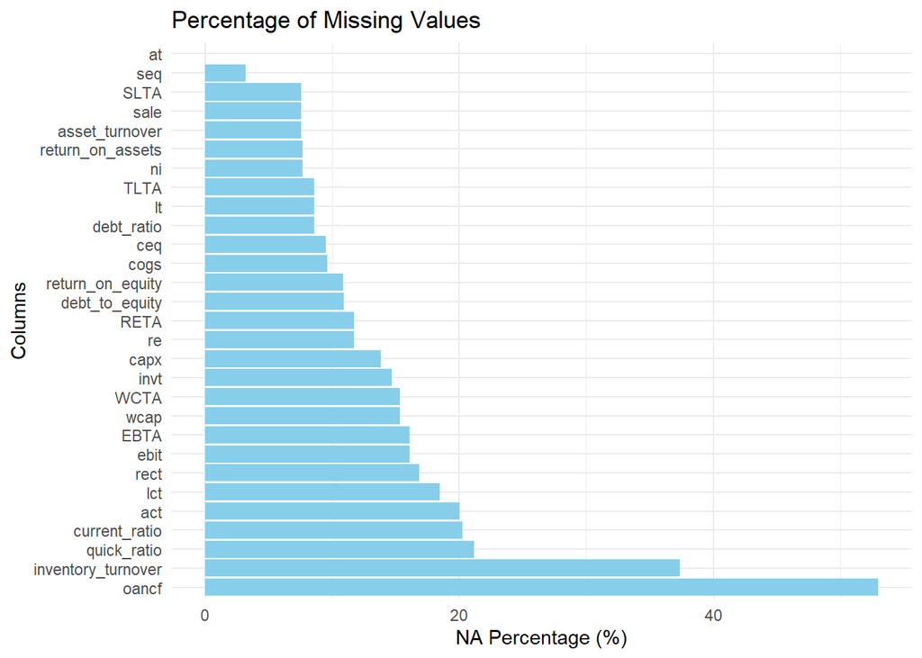

```r
print(df_analyze)
```

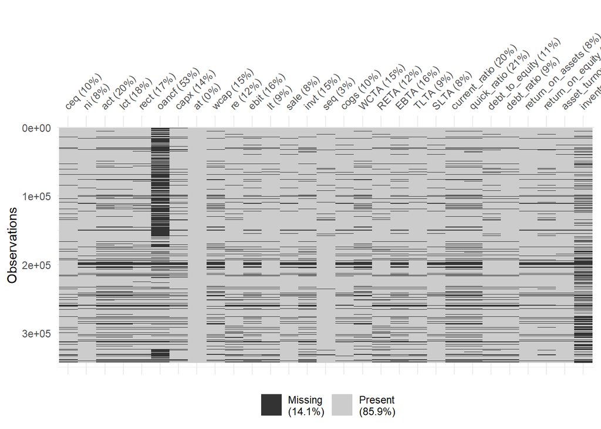

```r
# Visualization of the missing value
vis_miss(data, warn_large_data = FALSE)
```

```r
# Pourcentage de valeurs manquantes par colonne
data %>%
  summarise(across(everything(), ~ sum(is.na(.)) / n() * 100))
```

```
# A tibble: 1 × 29
    ceq    ni   act   lct  rect oancf  capx    at  wcap    re  ebit    lt  sale
  <dbl> <dbl> <dbl> <dbl> <dbl> <dbl> <dbl> <dbl> <dbl> <dbl> <dbl> <dbl> <dbl>
1  9.53  7.71  20.1  18.5  16.9  53.0  13.8     0  15.4  11.7  16.1  8.61  7.58
# ℹ 16 more variables: invt <dbl>, seq <dbl>, cogs <dbl>, WCTA <dbl>,
#   RETA <dbl>, EBTA <dbl>, TLTA <dbl>, SLTA <dbl>, current_ratio <dbl>,
#   quick_ratio <dbl>, debt_to_equity <dbl>, debt_ratio <dbl>,
#   return_on_assets <dbl>, return_on_equity <dbl>, asset_turnover <dbl>,
#   inventory_turnover <dbl>
```

```r
# Filter columns with NA_Percentage <= 50%
columns_to_keep <- df_analyze$data %>%
  filter(NA_Percentage <= 50) %>%
  pull(Column)

df_filtered <- data %>%
  select(all_of(columns_to_keep))
```

```r
# Apply multiple imputation for the remaining NA
cl <- makeCluster(detectCores() - 1)
registerDoParallel(cl)
imputed_data <- mice(df_filtered, m = 2, maxit = 20, method = "pmm", seed = 123)
stopCluster(cl)
```

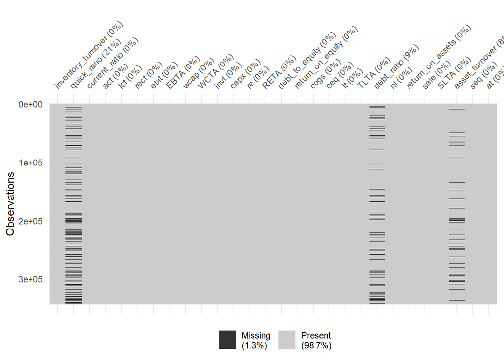

```r
df_imputed <- complete(imputed_data)
vis_miss(df_imputed, warn_large_data = FALSE)
```

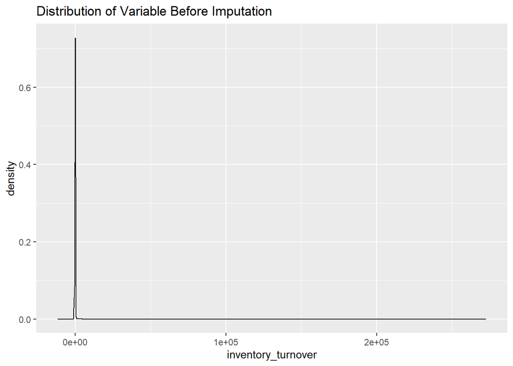

```r
# We can check is the imputation work well by comparing the distribution after and before the multiple imputation
ggplot(data = df, aes(x = inventory_turnover)) +
  geom_density() +
  labs(title = "Distribution of Variable Before Imputation")
```

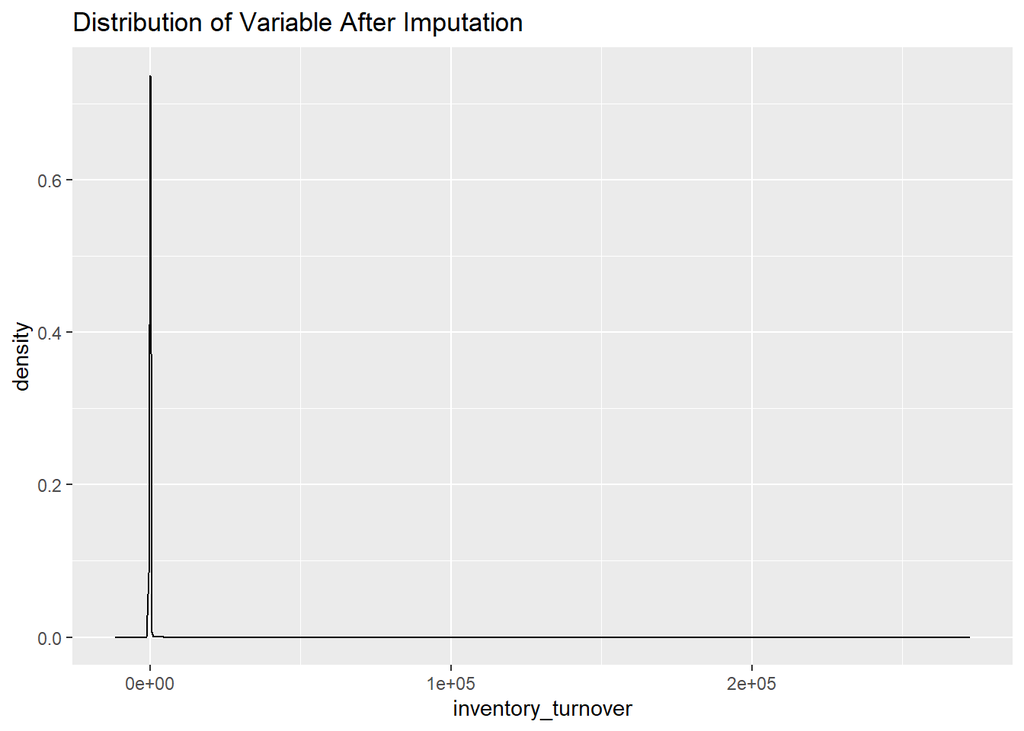

```r
ggplot(data = df_imputed, aes(x = inventory_turnover)) +
  geom_density() +
  labs(title = "Distribution of Variable After Imputation")
```

```r
# Drop variables (columns) that contain any NA
df_cleaned <- df_imputed %>%
  select(where(~ !any(is.na(.))))
```

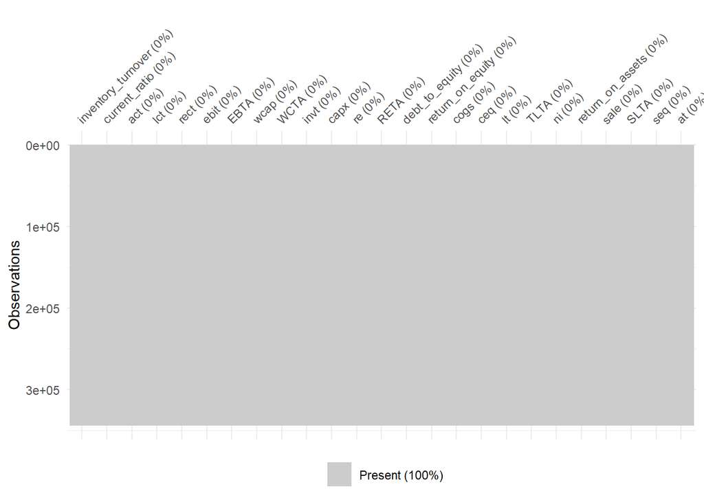

```r
vis_miss(df_cleaned, warn_large_data = FALSE)
```

```
[1] "Missing Values Analysis -"
                               Column NA_Count NA_Percentage
inventory_turnover inventory_turnover        0             0
current_ratio           current_ratio        0             0
act                               act        0             0
lct                               lct        0             0
rect                             rect        0             0
ebit                             ebit        0             0
EBTA                             EBTA        0             0
wcap                             wcap        0             0
WCTA                             WCTA        0             0
invt                             invt        0             0
capx                             capx        0             0
re                                 re        0             0
RETA                             RETA        0             0
debt_to_equity         debt_to_equity        0             0
return_on_equity     return_on_equity        0             0
cogs                             cogs        0             0
ceq                               ceq        0             0
lt                                 lt        0             0
TLTA                             TLTA        0             0
ni                                 ni        0             0
return_on_assets     return_on_assets        0             0
sale                             sale        0             0
SLTA                             SLTA        0             0
seq                               seq        0             0
at                                 at        0             0
```

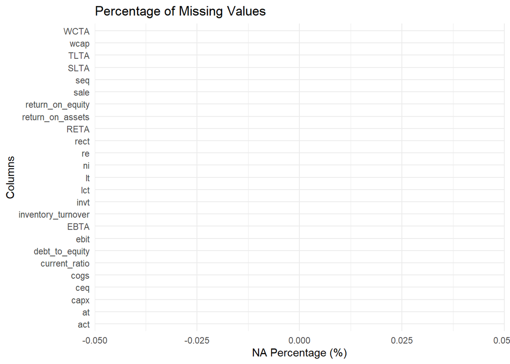

```r
print(analyze_na(df_cleaned))
```

Initially, we analyzed the distribution of missing values (NA) in the dataset and removed columns with more than 50% missing data. These columns were deemed uninformative and too challenging to impute reliably. Next, we performed multiple imputation using the `pmm` (Predictive Mean Matching) method for variables with less than 50% missing data. This approach allowed us to fill in the missing values by leveraging the statistical relationships between the remaining variables. However, after the multiple imputation, some variables, specifically `quick_ratio`, `debt_ratio`, and `asset_turnover`, still contained NA values. In a prior analysis, we had observed that these variables were highly correlated with others or provided similar information. As a result, their removal did not pose any issues and simplified the dataset while preserving its integrity and relevance. The final dataset is now complete, ready for further analysis or modeling, with reliable and coherent data.

### Study of Correlation with Outliers and Without

After the cleaning of our dataset, we want to study the correlation matrix, and visualizing it as a heatmap

```r
df_cleaned$fyear <- df$fyear
df_cleaned$Y_lopucki <- df$Y_lopucki
cor_with_outliers <- cor(df_cleaned, use = "pairwise.complete.obs")
print(cor_with_outliers)
```

```
                   inventory_turnover current_ratio           act          lct
inventory_turnover       1.0000000000 -0.0001375424  0.0074626974  0.009788393
current_ratio           -0.0001375424  1.0000000000 -0.0054571658 -0.005468074
act                      0.0074626974 -0.0054571658  1.0000000000  0.961939276
lct                      0.0097883929 -0.0054680738  0.9619392763  1.000000000
rect                     0.0115851686 -0.0024589076  0.6671483443  0.698946244
ebit                     0.0088670361 -0.0059173485  0.7086309827  0.693729909
EBTA                    -0.0033686587  0.0008131359 -0.0072886911 -0.008348662
wcap                    -0.0106280219  0.0016893937 -0.1633087954 -0.426505383
WCTA                    -0.0039861774  0.0012283644 -0.0059382132 -0.009972293
invt                    -0.0002962864 -0.0020185710  0.3916640017  0.409743966
capx                     0.0010073320 -0.0070246540  0.5754189720  0.555408954
re                       0.0016953032 -0.0004019178  0.3111101322  0.298510671
RETA                    -0.0106412794  0.0018491453 -0.0062076109 -0.007222076
debt_to_equity           0.0023302014 -0.0003328678  0.0017833187  0.001349459
return_on_equity        -0.0001095776 -0.0005633672  0.0002236291  0.000163257
cogs                     0.0026179321 -0.0072870736  0.6962497518  0.647003617
ceq                      0.0023598632  0.0011269848  0.2555554910  0.244158274
lt                       0.0060850690 -0.0048922650  0.5849068804  0.612447726
TLTA                     0.0039879543 -0.0012329404  0.0012653298  0.004361404
ni                       0.0005994592 -0.0016743894  0.1934752058  0.164901811
return_on_assets        -0.0027966645  0.0006696371 -0.0021456104 -0.006029163
sale                     0.0033936204 -0.0078491695  0.7724438823  0.719790627
SLTA                     0.0053590001 -0.0027603719  0.0022450004  0.002099326
seq                      0.0026443250 -0.0055021603  0.6519208608  0.620473864
at                       0.0090435145 -0.0039860272  0.8087697704  0.840494226
fyear                    0.0083881399  0.0136714040  0.0851126834  0.072411611
Y_lopucki                0.0005893335  0.0002143438  0.0008621699  0.005915411
                            rect         ebit          EBTA          wcap
inventory_turnover  0.0115851686  0.008867036 -3.368659e-03 -0.0106280219
current_ratio      -0.0024589076 -0.005917349  8.131359e-04  0.0016893937
act                 0.6671483443  0.708630983 -7.288691e-03 -0.1633087954
lct                 0.6989462439  0.693729909 -8.348662e-03 -0.4265053829
rect                1.0000000000  0.694566754 -7.674037e-03 -0.3141874542
ebit                0.6945667543  1.000000000 -6.125508e-03 -0.1569317834
EBTA               -0.0076740374 -0.006125508  1.000000e+00  0.0060396113
wcap               -0.3141874542 -0.156931783  6.039611e-03  1.0000000000
WCTA               -0.0087983966 -0.006640362  1.284687e-01  0.0164244674
invt                0.4888597705  0.447702674 -1.688943e-03 -0.1726337578
capx                0.2573086126  0.556242693 -5.308862e-03 -0.1029482541
```

[output cut: 141 more lines]

```
RETA               -0.005587189 -0.029850092  0.0013298036
debt_to_equity      0.001556163 -0.002921755 -0.0006455250
return_on_equity   -0.001532241 -0.001201633  0.0004218878
cogs                0.418190261  0.076194398  0.0027238748
ceq                 0.241132709  0.021563924 -0.0205909484
lt                  0.732672128  0.045699059  0.0146446380
TLTA                0.001121092  0.014654711  0.0004262850
ni                  0.150178966  0.009890498 -0.0249114945
return_on_assets   -0.003458355 -0.012952054  0.0009941848
sale                0.513556705  0.087548650  0.0009244692
SLTA                0.002014598 -0.011999121 -0.0005571055
seq                 0.589448621  0.090610059 -0.0078335928
at                  1.000000000  0.056865644  0.0036345083
fyear               0.056865644  1.000000000  0.0309526343
Y_lopucki           0.003634508  0.030952634  1.0000000000
```

```
[1] "Missing Values Analysis -"
                               Column NA_Count NA_Percentage
inventory_turnover inventory_turnover        0             0
current_ratio           current_ratio        0             0
act                               act        0             0
lct                               lct        0             0
rect                             rect        0             0
ebit                             ebit        0             0
EBTA                             EBTA        0             0
wcap                             wcap        0             0
WCTA                             WCTA        0             0
invt                             invt        0             0
capx                             capx        0             0
re                                 re        0             0
RETA                             RETA        0             0
debt_to_equity         debt_to_equity        0             0
return_on_equity     return_on_equity        0             0
cogs                             cogs        0             0
ceq                               ceq        0             0
lt                                 lt        0             0
TLTA                             TLTA        0             0
ni                                 ni        0             0
return_on_assets     return_on_assets        0             0
sale                             sale        0             0
SLTA                             SLTA        0             0
seq                               seq        0             0
at                                 at        0             0
fyear                           fyear        0             0
Y_lopucki                   Y_lopucki        0             0
```

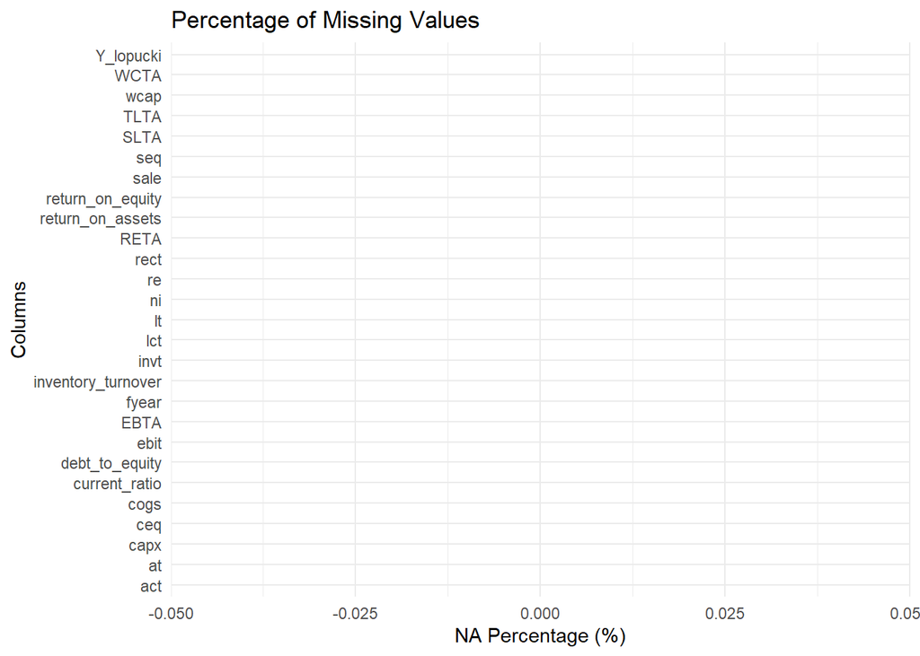

```r
print(analyze_na(df_cleaned))
```

```r
table(df_cleaned$Y_lopucki)
```

```
     0      1
341391   2545
```

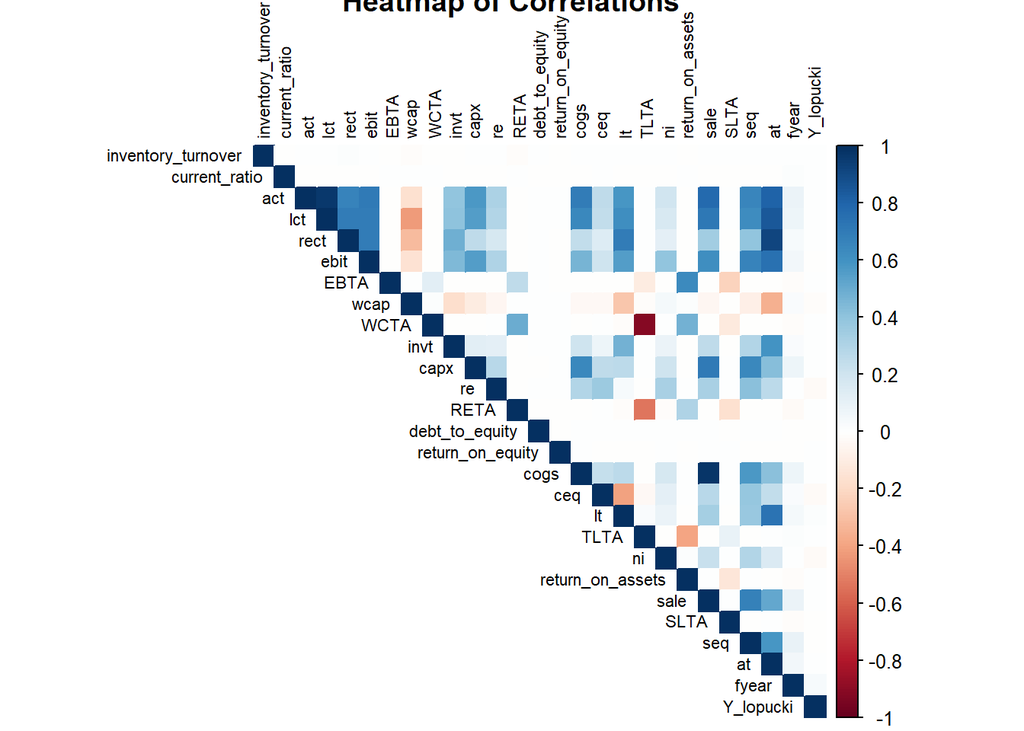

```r
# Create a heatmap of the correlation matrix
corrplot(cor_with_outliers, method = "color", type = "upper",
         tl.col = "black", tl.cex = 0.7, title = "Heatmap of Correlations")
```

The idea of the following code is to identify pairs of variables that have a high correlation (absolute value greater than 0.8). The code first extracts the indices of highly correlated pairs and exclude self-correlations. The output shows us the pairs of variables and their corresponding correlation values.

```r
# Find high correlations (absolute value > 0.8)
high_corr <- which(abs(cor_with_outliers) > 0.8, arr.ind = TRUE)

# Exclude self-correlations
high_corr <- high_corr[high_corr[, 1] != high_corr[, 2], ]

# Display highly correlated pairs
print(data.frame(
  Variable1 = rownames(cor_with_outliers)[high_corr[, 1]],
  Variable2 = colnames(cor_with_outliers)[high_corr[, 2]],
  Correlation = cor_with_outliers[high_corr]
))
```

```
   Variable1 Variable2 Correlation
1        lct       act   0.9619393
2         at       act   0.8087698
3        act       lct   0.9619393
4         at       lct   0.8404942
5         at      rect   0.9122901
6       TLTA      WCTA  -0.9187587
7       sale      cogs   0.9728283
8       WCTA      TLTA  -0.9187587
9       cogs      sale   0.9728283
10       act        at   0.8087698
11       lct        at   0.8404942
12      rect        at   0.9122901
```

Let’s check for the multicolinearity now. The VIF analysis checks it. High values may indicate that certain predictors are highly correlated with each other, which leads to overfitting or unreliable coefficients in a model.

```r
data_for_vif <- df_cleaned %>% select(-c("fyear"))
vif_model <- lm(Y_lopucki  ~ ., data = data_for_vif)

vif(vif_model)
```

```
inventory_turnover      current_ratio                act                lct
          1.000438           1.000099        9942.261101       11738.651982
              rect               ebit               EBTA               wcap
         10.209178           5.925223           1.923488         903.604054
              WCTA               invt               capx                 re
          7.232110           2.220314           2.536045           1.388908
              RETA     debt_to_equity   return_on_equity               cogs
          1.490488           1.000043           1.000125          43.103225
               ceq                 lt               TLTA                 ni
          6.219956          11.403328           6.908820           1.376111
  return_on_assets               sale               SLTA                seq
          2.280089          63.196097           1.076841           3.613390
                at
         26.534828
```

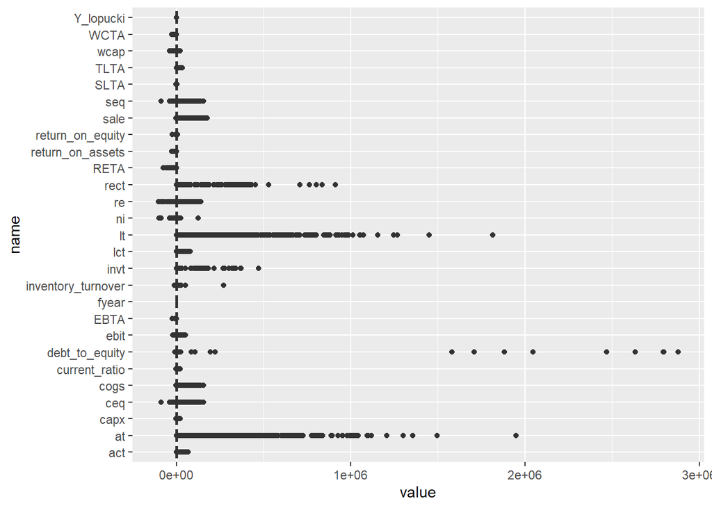

```r
df_cleaned %>%
  pivot_longer(where(is.numeric)) %>%
  ggplot(aes(x = name, y = value)) +
  geom_boxplot() +
  coord_flip()
```

```
[1] "Missing Values Analysis -"
                               Column NA_Count NA_Percentage
inventory_turnover inventory_turnover        0             0
current_ratio           current_ratio        0             0
act                               act        0             0
lct                               lct        0             0
rect                             rect        0             0
ebit                             ebit        0             0
EBTA                             EBTA        0             0
wcap                             wcap        0             0
WCTA                             WCTA        0             0
invt                             invt        0             0
capx                             capx        0             0
re                                 re        0             0
RETA                             RETA        0             0
debt_to_equity         debt_to_equity        0             0
return_on_equity     return_on_equity        0             0
cogs                             cogs        0             0
ceq                               ceq        0             0
lt                                 lt        0             0
TLTA                             TLTA        0             0
ni                                 ni        0             0
return_on_assets     return_on_assets        0             0
sale                             sale        0             0
SLTA                             SLTA        0             0
seq                               seq        0             0
at                                 at        0             0
fyear                           fyear        0             0
Y_lopucki                   Y_lopucki        0             0
```

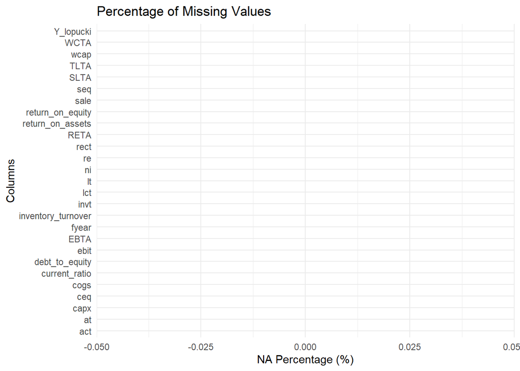

```r
print(analyze_na(df_cleaned))
```

```r
# Winsorizarion
winsorize <- function(x, lower = 0.01, upper = 0.99) {
  # Calculate lower and upper quantiles
  quantiles <- quantile(x, probs = c(lower, upper), na.rm = TRUE)
  # Cap values outside the quantile range
  pmin(pmax(x, quantiles[1]), quantiles[2])
}

df_clean <- df_cleaned %>%
  mutate(across(where(is.numeric) & !c(Y_lopucki, fyear), ~ winsorize(., 0.2,0.8)))
```

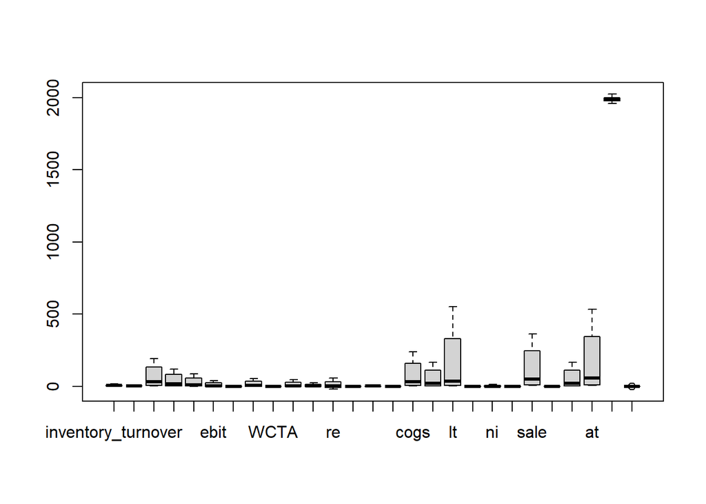

```r
boxplot(df_clean)
```

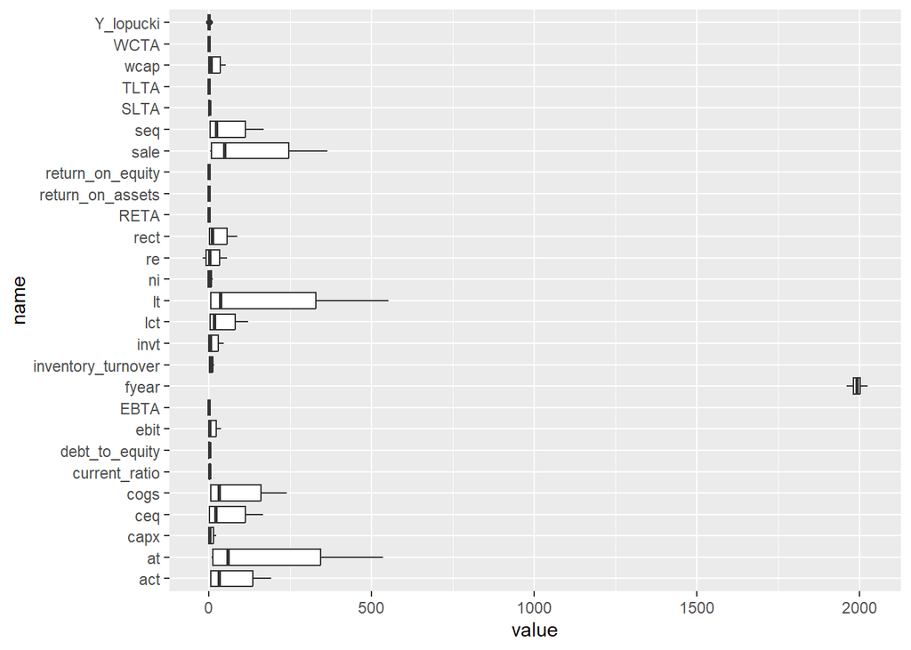

```r
df_clean %>%
  pivot_longer(where(is.numeric)) %>%
  ggplot(aes(x = name, y = value)) +
  geom_boxplot() +
  coord_flip()
```

To address the issue of outliers in the dataset, we applied Winsorization to all numeric variables, excluding `Y_lopucki` and `fyear`, as these are not appropriate for such transformation. Specifically, we used the 20th and 80th percentiles as thresholds, effectively capping extreme values at these limits. This approach ensures that outliers are mitigated while preserving the overall distribution and relationships within the data. The use of Winsorization at these thresholds was chosen to balance the reduction of extreme values with the retention of important data variability. By focusing on this range, we can limit the influence of extreme values without resorting to complete removal or severe transformations, thereby maintaining the integrity of the dataset for subsequent analysis.

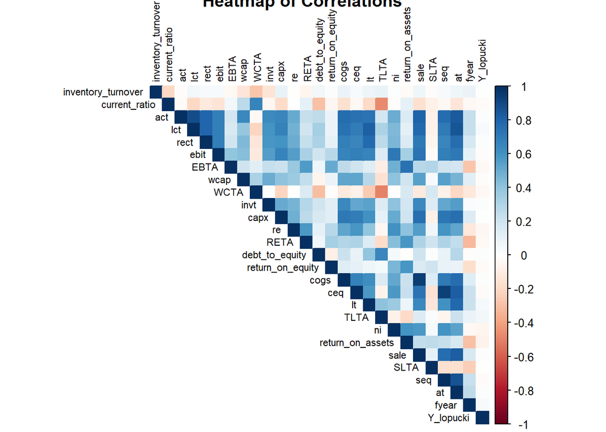

```r
correlation_matrix <- cor(df_clean, use = "pairwise.complete.obs")
corrplot(correlation_matrix, method = "color", type = "upper",
         tl.col = "black", tl.cex = 0.7, title = "Heatmap of Correlations")
```

```r
# Find high correlations (absolute value > 0.8)
high_corr <- which(abs(correlation_matrix) > 0.8, arr.ind = TRUE)

# Exclude self-correlations
high_corr <- high_corr[high_corr[, 1] != high_corr[, 2], ]

# Display highly correlated pairs
print(data.frame(
  Variable1 = rownames(correlation_matrix)[high_corr[, 1]],
  Variable2 = colnames(correlation_matrix)[high_corr[, 2]],
  Correlation = correlation_matrix[high_corr]
))
```

```
   Variable1 Variable2 Correlation
1        lct       act   0.8891007
2       sale       act   0.8040719
3         at       act   0.8378282
4        act       lct   0.8891007
5         lt       lct   0.8198438
6         at       lct   0.8512457
7       sale      cogs   0.9491095
8        seq       ceq   0.9353748
9         at       ceq   0.8202156
10       lct        lt   0.8198438
11       act      sale   0.8040719
12      cogs      sale   0.9491095
13        at      sale   0.8223672
14       ceq       seq   0.9353748
15        at       seq   0.8602477
16       act        at   0.8378282
17       lct        at   0.8512457
18       ceq        at   0.8202156
19      sale        at   0.8223672
20       seq        at   0.8602477
```

```r
data_vif <- df_clean %>% select(-c("fyear"))
vif_model <- lm(Y_lopucki  ~ ., data = data_vif)

vif(vif_model)
```

```
inventory_turnover      current_ratio                act                lct
          1.168404           2.139875          11.166536           9.618049
              rect               ebit               EBTA               wcap
          3.756673           4.278040           2.707700           3.099159
              WCTA               invt               capx                 re
          2.453805           2.258971           2.983865           2.436007
              RETA     debt_to_equity   return_on_equity               cogs
          2.166481           2.203250           1.922205          11.157061
               ceq                 lt               TLTA                 ni
          8.780540           4.833791           3.299846           3.521258
  return_on_assets               sale               SLTA                seq
          3.528887          15.937143           1.610192          11.782826
                at
          9.937981
```

```r
df_selected <- df_clean %>%
  select(-act, -seq, -lct, -cogs)


df_selected <- df_selected %>%
  filter(!is.na(Y_lopucki))
```

```r
saveRDS(df_selected, "final_databases.rds")
```